# Lab 1 Demo: Think Before You Code

## Part 0: Setup

Before importing a package, ask what type of work is needed:

- numerical summaries and arrays → `numpy`;
- tables and labelled columns → `pandas`;
- graphs → `matplotlib.pyplot`.

`import ... as ...` creates a short alias. For example, `np.mean(...)` means use the `mean` function from NumPy.

```python
import numpy as np
import pandas as pd
import matplotlib.pyplot as plt
```

## Part A: Explore input data before modelling

A campus print station has one printer. Seven print jobs arrive at different times and require different processing durations.

We ask:

- Are the two lists the same length?
- Are arrival times in chronological order?
- Are service times non-negative?
- What is typical: mean, median, or mode?
- Are there unusually long jobs?

```python
job = [1, 2, 3, 4, 5, 6, 7]                  # Job numbers
arrival = [0, 2, 5, 6, 10, 12, 16]           # Arrival time of each job
service = [2, 5, 3, 5, 2, 4, 5]              # Service (printing) time of each job
```

### A1. Numerical-summary commands

| Command | Meaning | Why it is useful |
| --- | --- | --- |
| `np.mean(x)` | arithmetic average | describes the average workload |
| `np.median(x)` | middle sorted value | less affected by extreme values |
| `pd.Series(x).mode()` | most frequent value or values | finds the most common duration |
| `np.min(x)` / `np.max(x)` | smallest / largest value | finds the range and possible extremes |
| `np.sum(x)` | total | finds total workload |
| `np.cumsum(x)` | running total | shows accumulated workload |
| `np.std(x)` | standard deviation | measures spread around the mean |
| `np.percentile(x, q)` | value at percentile `q` | describes the distribution beyond the mean |
| `np.argmax(x)` | position of the first maximum | identifies which record has the largest value |

A command answers a mathematical question; it does not interpret the system for us. We must explain what the returned number means in context.

```python
# Calculate the mean (average) service time
np.mean(service)
```

```
3.7142857142857144
```

```python
# Calculate the median service time
np.median(service)
```

```
4.0
```

```python
# Find the most common service time(s)
pd.Series(service).mode()
```

```
0    5
dtype: int64
```

```python
# Find the shortest service time
np.min(service)
```

```
2
```

```python
# Find the longest service time
np.max(service)
```

```
5
```

```python
# Calculate the total service time required for all jobs
np.sum(service)
```

```
26
```

```python
# Calculate the accumulated service time after each job
np.cumsum(service)
```

```
array([ 2,  7, 10, 15, 17, 21, 26])
```

```python
# Calculate the standard deviation of the service times
np.std(service)
```

```
1.2777531299998799
```

```python
# Calculate the first quartile, median, and third quartile
np.percentile(service,[25,50,75])
```

```
array([2.5, 4. , 5. ])
```

```python
# Find the first job with the longest service time
job[np.argmax(service)]
```

```
2
```

```python
np.argmax(service)
```

```
1
```

### A2. Build and inspect a DataFrame

`pd.DataFrame({...})` creates a labelled table from a dictionary. Dictionary keys become column names.

Useful inspection commands:

- `df.head()` displays the first rows;
- `df.shape` returns `(number_of_rows, number_of_columns)`;
- `df.dtypes` shows the data type of each column;
- `df.describe()` gives several numerical summaries;
- `df["column"]` selects one column;
- `df.loc[row, "column"]` selects by row label and column name;
- `df.sort_values(...)` sorts rows without changing their meaning;
- `df.query(...)` filters rows using a readable condition;
- `.diff()` subtracts the previous value from the current value.

```python
# Create a DataFrame to organise the job data into a table
jobs_df = pd.DataFrame({
    "job": job,            # Job number
    "arrival": arrival,    # Arrival time of each job
    "service": service,    # Service (printing) time of each job
})

# Calculate the time between consecutive job arrivals
jobs_df["interarrival"] = jobs_df["arrival"].diff()

# Display the DataFrame
jobs_df
```

|  | job | arrival | service | interarrival |
| --- | --- | --- | --- | --- |
| 0 | 1 | 0 | 2 | NaN |
| 1 | 2 | 2 | 5 | 2.0 |
| 2 | 3 | 5 | 3 | 3.0 |
| 3 | 4 | 6 | 5 | 1.0 |
| 4 | 5 | 10 | 2 | 4.0 |
| 5 | 6 | 12 | 4 | 2.0 |
| 6 | 7 | 16 | 5 | 4.0 |

```python
# Display the number of rows and columns in the DataFrame
print("Shape:", jobs_df.shape)

# Display the data type of each column
print("\nData types:")
print(jobs_df.dtypes)

# Display summary statistics for the numerical columns
print("\nNumerical description:")
display(jobs_df.describe())

# Select and display jobs with service time of at least 5 time units
print("Jobs requiring at least 5 time units:")
display(jobs_df.query("service >= 5"))

# Sort the jobs from longest to shortest service time
print("Jobs sorted by service time:")
display(jobs_df.sort_values("service", ascending=False))
```

```
Shape: (7, 4)

Data types:
job               int64
arrival           int64
service           int64
interarrival    float64
dtype: object

Numerical description:
```

|  | job | arrival | service | interarrival |
| --- | --- | --- | --- | --- |
| count | 7.000000 | 7.000000 | 7.000000 | 6.000000 |
| mean | 4.000000 | 7.285714 | 3.714286 | 2.666667 |
| std | 2.160247 | 5.677860 | 1.380131 | 1.211060 |
| min | 1.000000 | 0.000000 | 2.000000 | 1.000000 |
| 25% | 2.500000 | 3.500000 | 2.500000 | 2.000000 |
| 50% | 4.000000 | 6.000000 | 4.000000 | 2.500000 |
| 75% | 5.500000 | 11.000000 | 5.000000 | 3.750000 |
| max | 7.000000 | 16.000000 | 5.000000 | 4.000000 |

```
Jobs requiring at least 5 time units:
```

|  | job | arrival | service | interarrival |
| --- | --- | --- | --- | --- |
| 1 | 2 | 2 | 5 | 2.0 |
| 3 | 4 | 6 | 5 | 1.0 |
| 6 | 7 | 16 | 5 | 4.0 |

```
Jobs sorted by service time:
```

|  | job | arrival | service | interarrival |
| --- | --- | --- | --- | --- |
| 1 | 2 | 2 | 5 | 2.0 |
| 3 | 4 | 6 | 5 | 1.0 |
| 6 | 7 | 16 | 5 | 4.0 |
| 5 | 6 | 12 | 4 | 2.0 |
| 2 | 3 | 5 | 3 | 3.0 |
| 0 | 1 | 0 | 2 | NaN |
| 4 | 5 | 10 | 2 | 4.0 |

### A3. Plots

Choose a graph based on the question:

- line plot: how a value changes with order or time;
- bar chart: compare separate categories or jobs;
- histogram: examine the distribution of many values;
- scatter plot: examine the relationship between two numerical variables.

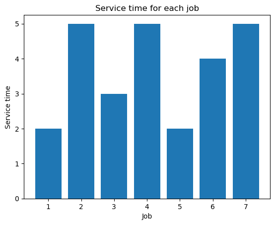

```python
# Create a bar chart: job number on the x-axis and service time on the y-axis
plt.bar(jobs_df["job"], jobs_df["service"])

# Label the horizontal axis
plt.xlabel("Job")

# Label the vertical axis
plt.ylabel("Service time")

# Add a title to the graph
plt.title("Service time for each job")

# Display the graph
plt.show()
```

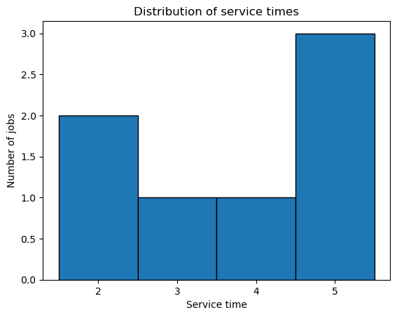

```python
# Create a histogram of the service times
# The bins are centred at service times 2, 3, 4, and 5
plt.hist(jobs_df["service"],  bins=np.arange(1.5, 6.5, 1), edgecolor="black")
plt.xlabel("Service time")
plt.ylabel("Number of jobs")
plt.title("Distribution of service times")
plt.xticks([2, 3, 4, 5])
plt.show()
```

## Part B: Describe the system before coding

Identify what exists in the model, what changes, what is random, and what should be measured.

| Concept | One-printer example | Reasoning |
| --- | --- | --- |
| Entity | Print job | It moves through the system |
| Temporary entity | Print job | It arrives and leaves |
| Permanent entity | Printer | It remains in the system |
| Resource | One printer | Jobs compete for it |
| Activity | Printing a job | It takes time |
| Event 1 | Job arrival | It changes the queue or starts service |
| Event 2 | Printing completion | It releases the printer |
| State variable 1 | Number of waiting jobs | It changes after events |
| State variable 2 | Printer status | Idle or busy at a given time |
| Input | Interarrival and service times | They drive system behaviour |
| Output | Average wait, maximum queue, utilisation | They evaluate performance |

A useful check is: *If I pause the simulation clock, can this variable describe the system now?* If yes, it may be a state variable.

## Part C: Choose a simulation worldview

Ask what the description is organised around:

- **Event scheduling:** What happens at the next arrival or completion?
- **Process interaction:** What does one print job experience?
- **Activity scanning:** At this time step, which rules are enabled?

| Worldview | One-printer description | Useful when | Main caution |
| --- | --- | --- | --- |
| Event scheduling | Process the earliest job arrival or printing completion | Precise discrete-event logic is needed | Event-list code requires care |
| Process interaction | A job arrives, waits, prints, and leaves | Communicating the entity journey | A framework often manages hidden events |
| Activity scanning | Repeatedly test whether jobs arrive or printing finishes | Time-step rules are simple | Many checks occur when nothing changes |

The worldview is a modelling choice, not a Python command. Choose it before designing the algorithm.

## Part D: Step through the queue

The printer serves one job at a time using **FCFS (First-Come, First-Served)**.

For each job, we want to find:

- **start** — when printing begins
- **end** — when printing finishes
- **wait** — how long the job waits before printing

The first job can start when it arrives.

For every later job, printing can begin only when:

1. the job has arrived, and
2. the printer has finished the previous job.

Therefore,

$$ \text{start}_i = \max(\text{arrival}_i,\text{end}_{i-1}) $$

$$ \text{end}_i = \text{start}_i+\text{service}_i $$

$$ \text{wait}_i = \text{start}_i-\text{arrival}_i $$

```python
jobs_df
```

|  | job | arrival | service | interarrival |
| --- | --- | --- | --- | --- |
| 0 | 1 | 0 | 2 | NaN |
| 1 | 2 | 2 | 5 | 2.0 |
| 2 | 3 | 5 | 3 | 3.0 |
| 3 | 4 | 6 | 5 | 1.0 |
| 4 | 5 | 10 | 2 | 4.0 |
| 5 | 6 | 12 | 4 | 2.0 |
| 6 | 7 | 16 | 5 | 4.0 |

```python
jobs_df.loc[0,"arrival"]
```

[output not shown]

```python
# Create new columns to store the simulation results
jobs_df["start"] = 0
jobs_df["end"] = 0
jobs_df["wait"] = 0

# Go through each job one at a time
for i in range(len(jobs_df)):

    # The first job can start as soon as it arrives
    if i == 0:
        jobs_df.loc[i, "start"] = jobs_df.loc[i, "arrival"]

    # Later jobs may have to wait for the previous job to finish
    else:
        jobs_df.loc[i, "start"] = max(
            jobs_df.loc[i, "arrival"],      # When this job arrives
            jobs_df.loc[i - 1, "end"]       # When the previous job finishes
        )

    # End time = start time + service time
    jobs_df.loc[i, "end"] = (
        jobs_df.loc[i, "start"] + jobs_df.loc[i, "service"]
    )

    # Waiting time = start time - arrival time
    jobs_df.loc[i, "wait"] = (
        jobs_df.loc[i, "start"] - jobs_df.loc[i, "arrival"]
    )

# Display the completed queue
jobs_df
```

|  | job | arrival | service | interarrival | start | end | wait |
| --- | --- | --- | --- | --- | --- | --- | --- |
| 0 | 1 | 0 | 2 | NaN | 0 | 2 | 0 |
| 1 | 2 | 2 | 5 | 2.0 | 2 | 7 | 0 |
| 2 | 3 | 5 | 3 | 3.0 | 7 | 10 | 2 |
| 3 | 4 | 6 | 5 | 1.0 | 10 | 15 | 4 |
| 4 | 5 | 10 | 2 | 4.0 | 15 | 17 | 5 |
| 5 | 6 | 12 | 4 | 2.0 | 17 | 21 | 5 |
| 6 | 7 | 16 | 5 | 4.0 | 21 | 26 | 5 |

### Think about the result

Look at Jobs 2, 3, and 4.

- Does Job 2 have to wait?
- Why does Job 3 have to wait?
- When does Job 4 start printing?
- Which job waits the longest?

Try to explain the results from the arrival and service times before using Python to calculate any summary statistics.

```python
# Calculate some summary statistics
average_wait = jobs_df["wait"].mean()
longest_wait = jobs_df["wait"].max()
last_completion = jobs_df["end"].max()

# Display the results
print("Average waiting time:", average_wait)
print("Longest waiting time:", longest_wait)
print("Last job completed at:", last_completion)
```

```
Average waiting time: 3.0
Longest waiting time: 5
Last job completed at: 26
```

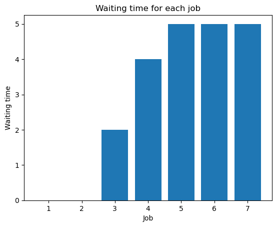

```python
# Plot the waiting time for each job

plt.bar(jobs_df["job"], jobs_df["wait"])
plt.xlabel("Job")
plt.ylabel("Waiting time")
plt.title("Waiting time for each job")
plt.show()
```

## Part E: Plan event logic with a flowchart

Represent decisions and state updates visually after understanding the queue calculation.

A computer-science **flowchart** shows actions, decisions, and direction of control. Use:

- rectangle → action or state update;
- diamond → decision;
- arrow → control direction;
- labels such as Yes and No → decision branches.

For a single printer, the essential event logic is:

```
Job arrival
    -> Is the printer idle?
        -> Yes: start printing
        -> No: join the queue

Printing completion
    -> Is the queue empty?
        -> Yes: make the printer idle
        -> No: remove the first waiting job and start printing
```

Before drawing, list the events, decisions, and state changes separately. Then connect them. Check that no branch removes a job from an empty queue and that every decision branch is labelled.

## Before starting the your lab

For every part, use the same cycle:

1. **Objective:** What modelling or Python skill is being practised?
2. **Think:** What should be true before running code?
3. **Choose:** Which command or data structure answers the question?
4. **Code:** Implement one small step.
5. **Inspect:** Read the table, graph, or error message.
6. **Verify:** Check logic with a manual result or invariant.
7. **Interpret:** Explain the result in the language of the real system.